# Reproducible Research: Peer Assessment 1

## Loading and preprocessing the data

```r
df = read.csv("activity.csv", header=TRUE)
```

## What is mean total number of steps taken per day?

Calculate the total number of steps taken per day:

```r
dayTotal = aggregate(df$steps, list(df$date), sum, na.rm=TRUE)
head(dayTotal)
```

```
##      Group.1     x
## 1 2012-10-01     0
## 2 2012-10-02   126
## 3 2012-10-03 11352
## 4 2012-10-04 12116
## 5 2012-10-05 13294
## 6 2012-10-06 15420
```

Make a histogram of the total number of steps taken each day. Here, I first calculate the number of bars needed to get a good representation of the data:

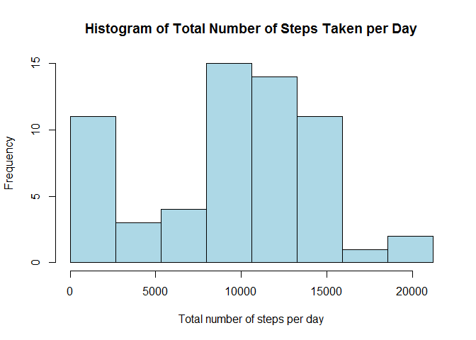

```r
width = round(sqrt(length(dayTotal$x)))
bars = seq(min(dayTotal$x), max(dayTotal$x), by=( (max(dayTotal$x) - min(dayTotal$x)) / width ))
hist(dayTotal$x, breaks = bars, main = "Histogram of Total Number of Steps Taken per Day",
     xlab = "Total number of steps per day", col = "lightblue")
```

Calculate and report the mean and median of the total number of steps taken per day (missing values are ignored):

```r
dayMean = aggregate(df$steps, list(df$date), mean, na.rm=TRUE)
dayMedian = aggregate(df$steps, list(df$date), median, na.rm=TRUE)
```

Below is the output for the mean number of steps taken per day.

```r
data.frame(Date = dayMean$Group.1, Mean = dayMean$x)
```

```
##          Date       Mean
## 1  2012-10-01        NaN
## 2  2012-10-02  0.4375000
## 3  2012-10-03 39.4166667
## 4  2012-10-04 42.0694444
## 5  2012-10-05 46.1597222
## 6  2012-10-06 53.5416667
## 7  2012-10-07 38.2465278
## 8  2012-10-08        NaN
## 9  2012-10-09 44.4826389
## 10 2012-10-10 34.3750000
## 11 2012-10-11 35.7777778
## 12 2012-10-12 60.3541667
## 13 2012-10-13 43.1458333
## 14 2012-10-14 52.4236111
```

[output cut: 47 more lines]

And here is the output for the median number of steps:

```r
data.frame(Date = dayMedian$Group.1, Median = dayMedian$x)
```

```
##          Date Median
## 1  2012-10-01     NA
## 2  2012-10-02      0
## 3  2012-10-03      0
## 4  2012-10-04      0
## 5  2012-10-05      0
## 6  2012-10-06      0
## 7  2012-10-07      0
## 8  2012-10-08     NA
## 9  2012-10-09      0
## 10 2012-10-10      0
## 11 2012-10-11      0
## 12 2012-10-12      0
## 13 2012-10-13      0
## 14 2012-10-14      0
```

[output cut: 47 more lines]

## What is the average daily activity pattern?

First, I calculate the mean number of steps for each day interval:

```r
intervals = as.factor(df$interval)
intervalMean = aggregate(df$steps, list(intervals), mean, na.rm=TRUE)
colnames(intervalMean) = c("Interval", "Mean")
```

Then, I create the time series plot of the 5-minute interval (x-axis) and the average number of steps taken, averaged across all days (y-axis):

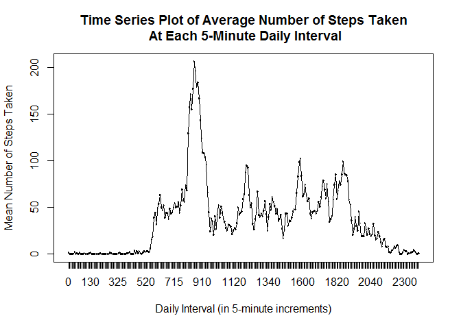

```r
plot(intervalMean$Mean ~ intervalMean$Interval,
     main = paste("Time Series Plot of Average Number of Steps Taken\n",
                  "At Each 5-Minute Daily Interval"),
     xlab = "Daily Interval (in 5-minute increments)",
     ylab = "Mean Number of Steps Taken")
lines(intervalMean$Mean)
```

#### Which 5-minute interval, on average across all the days in the dataset, contains the maximum number of steps?

```r
intervalMean[which(intervalMean$Mean == max(intervalMean$Mean)),]
```

```
##     Interval     Mean
## 104      835 206.1698
```

In other words, interval 835 with mean 206.1698 steps.

## Inputing missing values

Calculate and report the total number of missing values in the dataset:

```r
length(which(is.na(df$steps) == TRUE))
```

```
## [1] 2304
```

Devise a strategy for filling in all of the missing values in the dataset. Here, I replace NAs with the mean value for the specific time interval:

```r
newSteps = df$steps
for (i in which(is.na(newSteps) == TRUE)) {
  newSteps[i] = intervalMean[which(intervalMean$Interval == df$interval[i]),2]
}
```

Create a new dataset that is equal to the original dataset but with the missing data filled in:

```r
newDf = data.frame(newSteps, df$date, df$interval)
colnames(newDf) = c("steps", "date", "interval")
```

Make a histogram of the total number of steps taken each day:

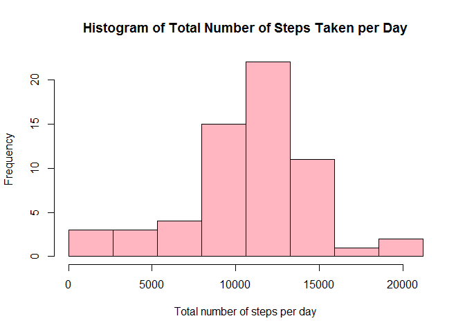

```r
newDayTotal = aggregate(newDf$steps, list(newDf$date), sum, na.rm=TRUE)
hist(newDayTotal$x, breaks = bars, main = "Histogram of Total Number of Steps Taken per Day",
     xlab = "Total number of steps per day", col = "lightpink")
```

Calculate and report the mean and median total number of steps taken per day:

```r
newDayMean = aggregate(newDf$steps, list(newDf$date), mean, na.rm=TRUE)
newDayMedian = aggregate(newDf$steps, list(newDf$date), median, na.rm=TRUE)
```

Below is the output for the means:

```r
data.frame(Date = newDayMean$Group.1, Mean = newDayMean$x)
```

```
##          Date       Mean
## 1  2012-10-01 37.3825996
## 2  2012-10-02  0.4375000
## 3  2012-10-03 39.4166667
## 4  2012-10-04 42.0694444
## 5  2012-10-05 46.1597222
## 6  2012-10-06 53.5416667
## 7  2012-10-07 38.2465278
## 8  2012-10-08 37.3825996
## 9  2012-10-09 44.4826389
## 10 2012-10-10 34.3750000
## 11 2012-10-11 35.7777778
## 12 2012-10-12 60.3541667
## 13 2012-10-13 43.1458333
## 14 2012-10-14 52.4236111
```

[output cut: 47 more lines]

And this is the output for the medians:

```r
data.frame(Date = newDayMedian$Group.1, Median = newDayMedian$x)
```

```
##          Date   Median
## 1  2012-10-01 34.11321
## 2  2012-10-02  0.00000
## 3  2012-10-03  0.00000
## 4  2012-10-04  0.00000
## 5  2012-10-05  0.00000
## 6  2012-10-06  0.00000
## 7  2012-10-07  0.00000
## 8  2012-10-08 34.11321
## 9  2012-10-09  0.00000
## 10 2012-10-10  0.00000
## 11 2012-10-11  0.00000
## 12 2012-10-12  0.00000
## 13 2012-10-13  0.00000
## 14 2012-10-14  0.00000
```

[output cut: 47 more lines]

#### Do these values differ from the estimates from the first part of the assignment?

Both the mean and the median differ from the estimates where there were previously NA values.

#### What is the impact of imputing missing data on the estimates of the total daily number of steps?

Since the NAs have been filled with the mean values, there is a greater frequency of totals at the center, resulting in a more bell-shaped distribution for the total step count.

## Are there differences in activity patterns between weekdays and weekends?

Create a new factor variable in the dataset with two levels - “weekday” and “weekend”:

```r
weekDay = weekdays(as.POSIXct(df$date))
newDf$dayType = as.factor(ifelse( (weekDay == "Saturday" | weekDay == "Sunday"),
                                 "weekend", "weekday"))
```

Calculating the interval means for weekdays and weekends:

```r
newIntervalMean = aggregate(newDf$steps, list(intervals,
                                              newDf$dayType == "weekend"), mean, na.rm=TRUE)
colnames(newIntervalMean) = c("Interval", "isWeekend", "Mean")
intMeanDay = newIntervalMean[newIntervalMean$isWeekend == FALSE, c(1,3)]
intMeanWeek = newIntervalMean[newIntervalMean$isWeekend == TRUE, c(1,3)]
```

Finally, here is the panel plot containing a time series plot of the 5-minute interval (x-axis) and the average number of steps taken, averaged across all weekday days or weekend days (y-axis):

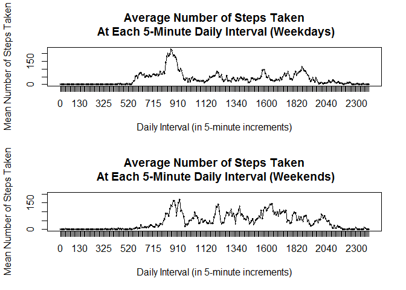

```r
par(mfrow=c(2,1))
plot(intMeanDay$Mean ~ intMeanDay$Interval,
     xlab = "Daily Interval (in 5-minute increments)",
     ylab = "Mean Number of Steps Taken")
lines(intMeanDay$Mean)
title(paste("Average Number of Steps Taken\n",
            "At Each 5-Minute Daily Interval (Weekdays)"))
plot(intMeanWeek$Mean ~ intMeanWeek$Interval,
     xlab = "Daily Interval (in 5-minute increments)",
     ylab = "Mean Number of Steps Taken",
     ylim = c(0,200))
lines(intMeanWeek$Mean)
title(paste("Average Number of Steps Taken\n",
            "At Each 5-Minute Daily Interval (Weekends)"))
```